# WHO Outbreak Extraction Coverage Report

2024-02-07

## WHO Outbreak Extraction Coverage Report

This report includes data on the temporal coverage achieved by the data extraction of outbreak locations from WHO external sitreps for 2023-2024 and some additional documents on a per country basis when the coverage was lacking.

```r
library(sf)
library(dplyr)
library(kableExtra)
library(lubridate)
```

```r
library(ggplot2)
```

```r
# load geopackages

folder_path <- "layers"
geopackage_files <- list.files(folder_path, pattern = "\\.gpkg$", full.names = TRUE)
geopackages <- list()

for (file_path in geopackage_files) {
  geopackage <- st_read(file_path)
  if (any(colnames(geopackage) == 'geom')){
    geopackage <- geopackage %>%
      rename(geometry = geom)
  }
  geopackages[[basename(file_path)]] <- geopackage
}



##load gpkg sent by javier that includes all admin unit polygons and select only the ADM0 level
countries <- st_read("ssa_admin_units.gpkg") %>%
  filter(admin_level == 'ADM0') %>%
  st_make_valid()

##add 'country' column to each geopackage
country_folder_path <- "layers/layers_with_country"
## for each geopackage
for (geopackage_name in names(geopackages)) {

  ##load
  geopackage <- geopackages[[geopackage_name]] %>% ##to only keep unique points
  group_by(geometry) %>%
  filter(row_number() == 1)

  ## spatial join between points and country polygons
  joined_data <- st_join(geopackage, countries) %>% ## to only keep unique rows
  group_by(geometry) %>%
  filter(row_number() == 1)

  ## add 'country' column to the original GeoPackage
  geopackage$country <- joined_data$country

  ## write to file
  write_sf(geopackage, file.path(country_folder_path, paste0(geopackage_name, "_with_country.gpkg")))
}

rm(geopackages)


## get list of geopackages
geopackage_files_with_country <- list.files(country_folder_path, pattern = "\\.gpkg$", full.names = TRUE)

geopackages_with_country <- list()

## loop through each file and load it
for (file_path in geopackage_files_with_country) {
  geopackage <- st_read(file_path)
  geopackages_with_country[[basename(file_path)]] <- geopackage %>%
  mutate(admin_level = as.integer(admin_level))
}

## add geopackage names
for (i in seq_along(geopackages_with_country)) {
  geopackages_with_country[[i]]$layer <- names(geopackages_with_country)[i]
}

# merge them into a single file
combined_geopackage <- bind_rows(geopackages_with_country, .id = "layer")

write_sf(combined_geopackage, file.path(country_folder_path, "combined_geopackage.gpkg"))
```

### Temporal reporting ranges per country from the WHO table

```r
who_reporting <- read.csv('who_reporting.csv') %>%
  mutate(time_left = as.Date(Reporting_start_date, format = "%m/%d/%Y")) %>%
  mutate(time_right = as.Date(Reporting_end_date, format = "%m/%d/%Y")) %>%
  mutate(reporting_interval = difftime(time_right, time_left, units = "days")) %>%
  select(Country, Country_code, time_left, time_right, reporting_interval)

kableExtra::kable(who_reporting, format = "html") %>%
  kable_styling(full_width = FALSE, position = "center", latex_options = "scale_down")
```

| Country | Country_code | time_left | time_right | reporting_interval |
| --- | --- | --- | --- | --- |
| Burundi | BDI | 2022-12-08 | 2023-12-10 | 367 days |
| Cameroon | CMR | 2021-10-01 | 2023-12-10 | 800 days |
| Congo | COG | 2023-07-17 | 2023-08-12 | 26 days |
| Democratic Republic of the Congo | COD | 2023-01-01 | 2023-12-04 | 337 days |
| Eswatini | ESW | 2023-03-27 | 2023-04-18 | 22 days |
| Ethiopia | ETH | 2022-08-01 | 2023-12-10 | 496 days |
| Kenya | KEN | 2022-10-05 | 2023-12-09 | 430 days |
| Malawi | MWI | 2022-02-28 | 2023-12-13 | 653 days |
| Mozambique | MOZ | 2022-09-01 | 2023-12-10 | 465 days |
| Nigeria | NGA | 2023-01-01 | 2023-11-11 | 314 days |
| South Africa | ZAF | 2023-01-29 | 2023-08-31 | 214 days |
| South Sudan | SSD | 2023-02-22 | 2023-03-18 | 24 days |
| Uganda | UGA | 2023-07-07 | 2023-09-14 | 69 days |
| United Republic of Tanzania | TZA | 2023-09-05 | 2023-12-14 | 100 days |
| Zambia | ZMB | 2023-10-11 | 2023-12-12 | 62 days |
| Togo | TGO | 2023-12-12 | 2023-12-12 | 0 days |
| Zimbabwe | ZWE | 2023-02-12 | 2023-12-10 | 301 days |
| Somalia | SOM | 2023-01-01 | 2023-12-09 | 342 days |
| Sudan | SDN | 2023-04-15 | 2023-12-08 | 237 days |

### Temporal reporting ranges per country from our data extraction

```r
##read geopackage and add difftime column
our_data <- st_read('combined_geopackage.gpkg') %>%
  mutate(reporting_interval = difftime(time_right, time_left, units = "days"))
our_reporting_unique <- our_data %>%
  select(time_left, time_right, country, layer, reporting_interval) %>%
  as.data.frame() %>%
  select(-geom) %>%
  unique() %>%
  na.omit() %>%
  mutate(country = ifelse(country == 'SWZ', 'ESW', country)) #rename SWZ to ESW


kableExtra::kable(our_reporting_unique, format = "html") %>%
  kable_styling(full_width = FALSE, position = "center", latex_options = "scale_down")
```

|  | time_left | time_right | country | layer | reporting_interval |
| --- | --- | --- | --- | --- | --- |
| 1 | 2023-01-01 | 2023-03-14 | COD | 20230320_multi-country_outbreak-of-cholera_sitrep-1_Figure_13_page_13.gpkg_with_country.gpkg | 72 days |
| 33 | 2023-03-13 | 2023-03-20 | MWI | 20230320_multi-country_outbreak-of-cholera_sitrep-1_Figure_3a_page_5.gpkg_with_country.gpkg | 7 days |
| 56 | 2022-09-12 | 2023-03-20 | MOZ | 20230320_multi-country_outbreak-of-cholera_sitrep-1_Figure_8a_page_8.gpkg_with_country.gpkg | 189 days |
| 94 | 2023-03-13 | 2023-03-19 | MOZ | 20230320_multi-country_outbreak-of-cholera_sitrep-1_Figure_8c_page_8.gpkg_with_country.gpkg | 6 days |
| 121 | 2023-01-01 | 2023-03-20 | BDI | 20230320_multi-country_outbreak-of-cholera_sitrep-1_Figure_9_inset_page_9.gpkg_with_country.gpkg | 78 days |
| 137 | 2023-01-01 | 2023-03-20 | COD | 20230320_multi-country_outbreak-of-cholera_sitrep-1_Figure_9_inset_page_9.gpkg_with_country.gpkg | 78 days |
| 147 | 2023-01-01 | 2023-03-20 | ZWE | 20230320_multi-country_outbreak-of-cholera_sitrep-1_Figure_9_page_9.gpkg_with_country.gpkg | 78 days |
| 153 | 2023-01-01 | 2023-03-20 | ZAF | 20230320_multi-country_outbreak-of-cholera_sitrep-1_Figure_9_page_9.gpkg_with_country.gpkg | 78 days |
| 155 | 2023-01-01 | 2023-03-20 | MOZ | 20230320_multi-country_outbreak-of-cholera_sitrep-1_Figure_9_page_9.gpkg_with_country.gpkg | 78 days |
| 165 | 2023-01-01 | 2023-03-20 | ZMB | 20230320_multi-country_outbreak-of-cholera_sitrep-1_Figure_9_page_9.gpkg_with_country.gpkg | 78 days |
| 192 | 2023-01-01 | 2023-03-20 | MWI | 20230320_multi-country_outbreak-of-cholera_sitrep-1_Figure_9_page_9.gpkg_with_country.gpkg | 78 days |
| 211 | 2023-01-01 | 2023-03-20 | COD | 20230320_multi-country_outbreak-of-cholera_sitrep-1_Figure_9_page_9.gpkg_with_country.gpkg | 78 days |
| 212 | 2023-01-01 | 2023-03-20 | TZA | 20230320_multi-country_outbreak-of-cholera_sitrep-1_Figure_9_page_9.gpkg_with_country.gpkg | 78 days |
| 280 | 2023-01-01 | 2023-03-20 | RWA | 20230320_multi-country_outbreak-of-cholera_sitrep-1_Figure_9_page_9.gpkg_with_country.gpkg | 78 days |
| 291 | 2023-04-09 | 2023-04-16 | MWI | 20230504_multi-country_outbreak-of-cholera_sitrep-2_updated_Figure_2a_page_5.gpkg_with_country.gpkg | 7 days |
| 309 | 2023-02-12 | 2023-04-18 | ZWE | 20230504_multi-country_outbreak-of-cholera_sitrep-2_updated_Figure_5_page_8.gpkg_with_country.gpkg | 65 days |
| 318 | 2023-01-01 | 2023-01-31 | KEN | 20230504_multi-country_outbreak-of-cholera_sitrep-2_updated_Figure_7a_page_9.gpkg_with_country.gpkg | 30 days |
| 321 | 2023-01-01 | 2023-01-31 | SOM | 20230504_multi-country_outbreak-of-cholera_sitrep-2_updated_Figure_7a_page_9.gpkg_with_country.gpkg | 30 days |
| 339 | 2023-01-01 | 2023-01-31 | ETH | 20230504_multi-country_outbreak-of-cholera_sitrep-2_updated_Figure_7a_page_9.gpkg_with_country.gpkg | 30 days |
| 342 | 2023-01-01 | 2023-04-16 | COD | 20230504_multi-country_outbreak-of-cholera_sitrep-2_updated_Figure_8a_page_10.gpkg_with_country.gpkg | 105 days |
| 357 | 2023-03-18 | 2023-04-16 | COD | 20230504_multi-country_outbreak-of-cholera_sitrep-2_updated_Figure_8b_page_10.gpkg_with_country.gpkg | 29 days |
| 366 | 2023-02-01 | 2023-02-28 | KEN | 20230522_multi-country_outbreak-of-cholera_sitrep-3_Figure_11a_page_12.gpkg_with_country.gpkg | 27 days |
| 376 | 2023-02-01 | 2023-02-28 | SOM | 20230522_multi-country_outbreak-of-cholera_sitrep-3_Figure_11a_page_12.gpkg_with_country.gpkg | 27 days |
| 384 | 2023-02-01 | 2023-02-28 | ETH | 20230522_multi-country_outbreak-of-cholera_sitrep-3_Figure_11a_page_12.gpkg_with_country.gpkg | 27 days |
| 389 | 2023-03-25 | 2023-05-14 | CMR | 20230522_multi-country_outbreak-of-cholera_sitrep-3_Figure_13_page_13.gpkg_with_country.gpkg | 50 days |
| 394 | 2023-02-01 | 2023-02-28 | BDI | 20230522_multi-country_outbreak-of-cholera_sitrep-3_Figure_2a_inset_page_4.gpkg_with_country.gpkg | 27 days |
| 397 | 2023-02-01 | 2023-02-28 | COD | 20230522_multi-country_outbreak-of-cholera_sitrep-3_Figure_2a_inset_page_4.gpkg_with_country.gpkg | 27 days |
| 417 | 2023-02-01 | 2023-02-28 | MOZ | 20230522_multi-country_outbreak-of-cholera_sitrep-3_Figure_2a_page_4.gpkg_with_country.gpkg | 27 days |
| 418 | 2023-02-01 | 2023-02-28 | ZAF | 20230522_multi-country_outbreak-of-cholera_sitrep-3_Figure_2a_page_4.gpkg_with_country.gpkg | 27 days |
| 419 | 2023-02-01 | 2023-02-28 | ZWE | 20230522_multi-country_outbreak-of-cholera_sitrep-3_Figure_2a_page_4.gpkg_with_country.gpkg | 27 days |

[output cut: 163 more lines]

### Number of layers extracted per country

```r
nlayers_by_country <- our_reporting_unique %>%
  group_by(country) %>%
  summarise(length(layer)) %>%
  rename('number of layers' = 'length(layer)')

kableExtra::kable(nlayers_by_country, format = "html") %>%
  kable_styling(full_width = FALSE, position = "left", latex_options = "scale_down")
```

| country | number of layers |
| --- | --- |
| BDI | 13 |
| CMR | 2 |
| COD | 28 |
| ESW | 2 |
| ETH | 12 |
| KEN | 11 |
| MOZ | 22 |
| MWI | 18 |
| NGA | 2 |
| RWA | 3 |
| SDN | 7 |
| SOM | 12 |
| TGO | 1 |
| TZA | 16 |
| UGA | 4 |
| ZAF | 8 |
| ZMB | 12 |
| ZWE | 20 |

## Table 1. WHO ‘missingness’, the number of days our data extractions cover from the WHO reported intervals and the number of days missing from the WHO reported interval

Table 1 includes metrics that indicate how fully our data extractions cover the interval reported by the WHO. NA cells mean that the country is included in the WHO table but we have no data extractions for it.

First, missingness is a metric that captures how incomplete our temporal coverage is for a given country compared to the coverage reported in the WHO table.

It is calculated as 1 minus the ratio of the number of unique days in our data collection (after treating the data for temporal overlaps) that fall within the reported interval in the WHO table and the reported interval in the WHO table and should take values 0-1.

The table also includes the number of unique days our data extractions cover from the WHO interval and the number of days missing.

Note that for the calculation of the metrics above we filter out temporal information that does not fall inside the WHO interval for each country. This information is included in Table 2.

```r
## to crop our reporting intervals to the range included in the WHO table
## this ensures that we do not include data from other sources and that our missingness is a number from 0 to 1
who_reporting <- who_reporting %>%
  rename(country = Country_code)

## function that calculates reporting 'missingness' per country

who_missingness <- function(who_table, data_extraction, cntry){

  ##to make sure we don't use the functions on countries not in the WHO table or in our data

  if (!cntry %in% who_table$country){
    stop(paste0(cntry, " not in WHO table"))
  }

  if (!cntry %in% data_extraction$country){
    stop(paste0(cntry, " not in our data"))
  }


  ##load who reporting period for the country
  who_country <- who_table %>%
    filter(country == cntry)

  ##load our data for that country
  data_extraction <- data_extraction %>%
    filter(country == cntry) %>%
    select(time_left, time_right) %>%
    unique()

  ##if an interval is completely outside the WHO interval, remove it

  keep <- c() ##intialise empty logical vector to filter rows based on this condition

  for (i in 1:nrow(data_extraction)){
    if (data_extraction$time_left[i] < who_country$time_left & data_extraction$time_right[i]  < who_country$time_left){
      keep[i] <- FALSE
    } else if (data_extraction$time_left[i] > who_country$time_right){
      keep[i] <- FALSE
    } else {
      keep[i] <- TRUE
    }
  }

  data_extraction <- data_extraction[keep,] #keep only rows that are inside the who interval

  ##If there are no rows left after filtering, we do not have info on the interval reported by the WHO

  if (nrow(data_extraction) == 0){
    stop("we do not have temporal information for the interval reported in the WHO table")
  }

##adjust TL and TR so that they fall inside the WHO reporting window (we are not interested in data from  ##other sources to calculate the WHO 'missingness' metric)

  for (i in 1:nrow(data_extraction)){
    if (data_extraction$time_left[i] < who_country$time_left){ #crop TL to WHO TL if interval starts earlier
      data_extraction$time_left[i] <- who_country$time_left
    }

    if (data_extraction$time_right[i] > who_country$time_right){ #crop TR to WHO TR if interval ends later
      data_extraction$time_right[i] <- who_country$time_right
  }

}

##to deal with overlaps for countries with more than one recorded interval, implement this procedure
## 1. arrange rows in order of increasing TL
## 2. loop from index 2 until the last row
## if TL[i] < TR[i-1] then TR[i-1] becomes equal to TL[i]
## this gives us rows with unique intervals and their duration

  data_extraction <- data_extraction %>%
    arrange(time_left)


  if (nrow(data_extraction) > 1){  ##only for countries with multiple intervals
    for (i in 2:nrow(data_extraction)){
      if (data_extraction$time_left[i] < data_extraction$time_right[i-1]){
        data_extraction$time_right[i-1] <- data_extraction$time_left[i]
      }
    }
  }

  data_extraction <- data_extraction %>%
    unique() %>%
    mutate(number_unique_days = difftime(time_right, time_left, units = 'days'))

  ## add up the duration of unique intervals to get the number of unique days covered per country

  num_days_covered <- sum(data_extraction$number_unique_days)

  ##subtract them from who interval to get number of days missing
  num_days_missing <- who_country$reporting_interval - num_days_covered


  ## divide our coverage by the who reporting interval to get a ratio that is the 'completeness' per country

  our_coverage <- as.numeric(num_days_covered)
  missing_coverage <- as.numeric(num_days_missing)
  who_coverage <- as.numeric(who_country$reporting_interval)

  ##this is for TGO which has a single case over one day, the 0 day time interval makes the division invalid

  if (our_coverage == 0){
    our_coverage <- 1
  }


  if (who_coverage == 0){
    who_coverage <- 1
  }


  completeness <- our_coverage/who_coverage

  ## calculate 1-completeness to get the 'missingness' of our data
  missingness <- 1-completeness

  if (missingness < 0){
    warning(paste0("there may be data collection errors leading to negative missingness, check who and our data for ",cntry))
  }

  table_with_stats <- as.data.frame(cbind(our_coverage, missing_coverage, missingness))


  return(table_with_stats)

}

##Apply function to every country that is both in the WHO table and our data

common_countries <- intersect(who_reporting$country, our_reporting_unique$country)

missingness_by_country <- c()
num_days_covered_by_country <- c()
num_days_missing_by_country <- c()

for (i in 1:length(common_countries)){
  missingness_by_country[i] <- as.numeric(round(who_missingness(who_reporting, our_reporting_unique, common_countries[i])[3], 2))
  num_days_covered_by_country[i] <- as.numeric(who_missingness(who_reporting, our_reporting_unique, common_countries[i])[1])
  num_days_missing_by_country[i] <- as.numeric(who_missingness(who_reporting, our_reporting_unique, common_countries[i])[2])
}

stats_table <- as.data.frame(cbind(common_countries, missingness_by_country, num_days_covered_by_country, num_days_missing_by_country)) %>%
  arrange(desc(missingness_by_country)) %>%
  rename(country = common_countries) %>%
  mutate(country = as.character(country))

##do a join with the WHO table countries to include the countries in the WHO table where we don't have any
## coverage in our data extraction

stats_table <- full_join(who_reporting, stats_table, by = 'country') %>%
  rename(country_code = country) %>%
  rename(country = Country) %>%
  rename(who_reporting_interval = reporting_interval)

##write to file
write.csv(stats_table, file = "data_extraction_stats.csv")


##print table
kableExtra::kable(stats_table, format = "html") %>%
  kable_styling(full_width = FALSE, position = "left", latex_options = "scale_down")
```

| country | country_code | time_left | time_right | who_reporting_interval | missingness_by_country | num_days_covered_by_country | num_days_missing_by_country |
| --- | --- | --- | --- | --- | --- | --- | --- |
| Burundi | BDI | 2022-12-08 | 2023-12-10 | 367 days | 0.07 | 343 | 24 |
| Cameroon | CMR | 2021-10-01 | 2023-12-10 | 800 days | 0.33 | 534 | 266 |
| Congo | COG | 2023-07-17 | 2023-08-12 | 26 days | NA | NA | NA |
| Democratic Republic of the Congo | COD | 2023-01-01 | 2023-12-04 | 337 days | 0.03 | 327 | 10 |
| Eswatini | ESW | 2023-03-27 | 2023-04-18 | 22 days | 0.05 | 21 | 1 |
| Ethiopia | ETH | 2022-08-01 | 2023-12-10 | 496 days | 0.33 | 332 | 164 |
| Kenya | KEN | 2022-10-05 | 2023-12-09 | 430 days | 0.25 | 323 | 107 |
| Malawi | MWI | 2022-02-28 | 2023-12-13 | 653 days | 0.52 | 316 | 337 |
| Mozambique | MOZ | 2022-09-01 | 2023-12-10 | 465 days | 0.06 | 435 | 30 |
| Nigeria | NGA | 2023-01-01 | 2023-11-11 | 314 days | 0 | 314 | 0 |
| South Africa | ZAF | 2023-01-29 | 2023-08-31 | 214 days | 0.3 | 150 | 64 |
| South Sudan | SSD | 2023-02-22 | 2023-03-18 | 24 days | NA | NA | NA |
| Uganda | UGA | 2023-07-07 | 2023-09-14 | 69 days | 0.22 | 54 | 15 |
| United Republic of Tanzania | TZA | 2023-09-05 | 2023-12-14 | 100 days | 0.04 | 96 | 4 |
| Zambia | ZMB | 2023-10-11 | 2023-12-12 | 62 days | 0.03 | 60 | 2 |
| Togo | TGO | 2023-12-12 | 2023-12-12 | 0 days | 0 | 1 | 0 |
| Zimbabwe | ZWE | 2023-02-12 | 2023-12-10 | 301 days | 0.09 | 275 | 26 |
| Somalia | SOM | 2023-01-01 | 2023-12-09 | 342 days | 0.03 | 331 | 11 |
| Sudan | SDN | 2023-04-15 | 2023-12-08 | 237 days | 0.31 | 163 | 74 |

### Plot of the ‘missingness’ of our temporal coverage for each country compared to the WHO table

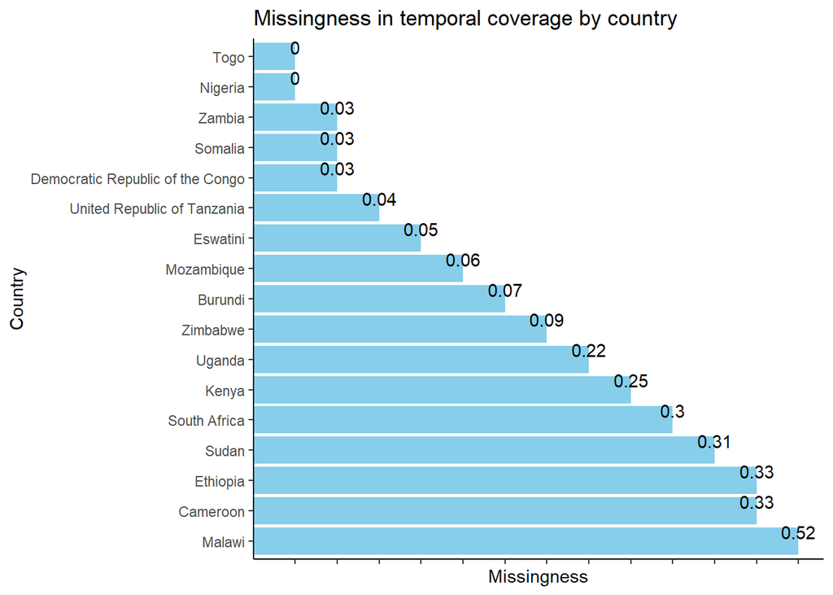

```r
stats_table <- stats_table %>%
  na.omit()

ggplot(stats_table, aes(x = reorder(country, desc(missingness_by_country)), y = missingness_by_country)) +
  geom_bar(stat = "identity", fill = "skyblue", position = position_dodge(width = 0.8)) +
  geom_text(aes(label = missingness_by_country), position = position_dodge(width = 0.8), vjust = -0.2) +
  labs(title = "Missingness in temporal coverage by country",
      x = "Country",
      y = "Missingness") +
  theme_classic() +
  coord_flip() +
  theme(axis.text.x = element_blank())
```

### Table 2. Number of unique days per country in our data coverage

Below is a table with the number of unique days per country in our temporal coverage. We deal with overlaps using the procedure used for the missingness calculation above.

Here we do not compare our coverage to the WHO table - we count the number of unique days our data cover to include any other sources (Nigeria sitreps, etc.)

```r
# table with number of unique days per country


##function calculating number of unique days in our coverage per country (treatin overlaps with procedure used ##previously)

calculate_unique_days <- function(our_coverage, cntry){

  ##load our data for that country
  our_coverage <- our_coverage %>%
    filter(country == cntry) %>%
    select(time_left, time_right) %>%
    unique()

  ##to deal with overlaps for countries with more than one recorded interval, implement this procedure
  ## 1. arrange rows in order of increasing TL
  ## 2. loop from index 2 until the last row
  ## if TL[i] < TR[i-1] then TR[i-1] becomes equal to TL[i]
  ## this gives us rows with unique intervals and their duration

  our_coverage <- our_coverage %>%
    arrange(time_left)


  if (nrow(our_coverage) > 1){  ##only for countries with multiple intervals
    for (i in 2:nrow(our_coverage)){
      if (our_coverage$time_left[i] < our_coverage$time_right[i-1]){
        our_coverage$time_right[i-1] <- our_coverage$time_left[i]
      }
    }
  }

  ## to get number of unique days select unique intervals
  our_coverage <- our_coverage %>%
    unique() %>%
    mutate(number_unique_days = difftime(time_right, time_left, units = 'days'))

  ## add up the duration of unique intervals to get the number of unique days covered per country

  num_days_covered <- sum(our_coverage$number_unique_days)

  return(num_days_covered)
}

##Apply function to every country that is in our data

our_countries <-unique(our_reporting_unique$country)

number_of_unique_days <- c()

for (i in 1:length(our_countries)){
  number_of_unique_days[i] <- calculate_unique_days(our_reporting_unique, our_countries[i])
}

number_of_unique_days_table <- as.data.frame(cbind(our_countries, number_of_unique_days)) %>%
  arrange(desc(number_of_unique_days))

kableExtra::kable(number_of_unique_days_table, format = "html") %>%
  kable_styling(full_width = FALSE, position = "left", latex_options = "scale_down")
```

| our_countries | number_of_unique_days |
| --- | --- |
| NGA | 726 |
| UGA | 60 |
| ESW | 59 |
| CMR | 534 |
| MOZ | 435 |
| BDI | 343 |
| ETH | 332 |
| SOM | 331 |
| COD | 327 |
| ZWE | 327 |
| KEN | 323 |
| MWI | 316 |
| ZMB | 272 |
| TZA | 244 |
| ZAF | 178 |
| SDN | 163 |
| RWA | 137 |
| TGO | 0 |